# Successive COVID-19 Waves Analysis

Imane Krourou

## Part 1

# Introduction

This study focuses on analyzing how hospitals adapted and recovered post-COVID surges, specifically focusing on ICU bed capacities and their impact on mortality rates during the waves of the pandemic. This research is crucial for understanding the effectiveness of hospital responses and preparing for future surges.

# Methods

# Results

## Data preparation

This dataset was first subset to select only the variables which were directly applicable to this study. These included the date, new cases, Covid-19 related deaths, information hospital bed capacities and ICU bed capacities.

Here I selected only the relevant variables

Then I subsetted the data

To ensure consistency in the analysis of the selected variables, the base date was set to January 01, 2021.

Here I defined the base date and then subsetted the data based on the common base date

### Trend analysis.

Here I plotted ICU capacities and mortality trends over time

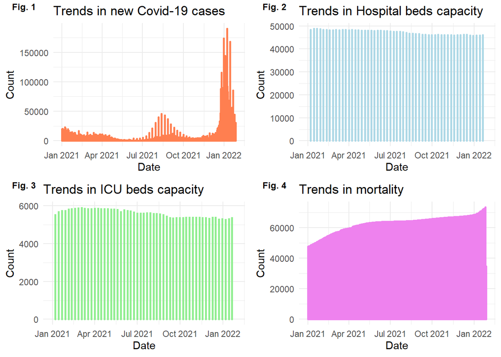

Based on the trend analysis of new cases in Fig. 1, about four Covid-19 surges can be recognized throughout the period under consideration. Similar to the number of ICU bed capacity displayed on Fig. 3, the overall number of hospital beds as shown in Fig. 2 looks to drop approaching the year 2022. On the other hand, as Fig. 4 illustrates, the number of deaths has increased steadily during the monitoring period.

### Covid-19 new cases surge waves between 1st January 2021 and 31st January 2022

It looks that the initial rise in 2021 lasted until the middle of February, and then there will be a second, lesser surge from the middle of February to the middle of May. Between July and October, there is another spike in new cases, with the biggest spike occurring from the middle of November until the end of the observation period. To show the surges, a new “wave” variable was established.  
So I created a new variable ‘wave’ indicating the wave for each observation

#### Summary table of Covid-19 surge waves

Table 1. Summary data of Covid-19 surge waves between 01-01-2021 and 31-01-2022

| wave | avg_newCases | avg_BedsCapacity | avg_ICUBedsCapacity | avg_deaths | avg_bedsusage | avg_ICUcovidusage |
| --- | --- | --- | --- | --- | --- | --- |
| 1 | 169.14238 | 764.4185 | 98.37719 | 417.6677 | 123.72068 | 33.51032 |
| 2 | 59.53696 | 759.5148 | 95.98537 | 548.3396 | 52.68745 | 16.76641 |
| 3 | 105.30281 | 753.3630 | 94.99686 | 630.7216 | 71.25103 | 21.86484 |
| 4 | 357.75791 | 743.7741 | 92.02432 | 804.8701 | 91.90895 | 20.77926 |

An overview of the Covid-19 surge waves seen between January 1, 2021, and January 31, 2022 is shown in Table 1. The number of new cases (avg_newCases), total hospital bed capacity (avg_BedsCapacity), ICU bed capacity (avg_ICUBedsCapacity), average bed usage (avg_bedsusage), and average ICU COVID usage (avg_ICUcovidusage) during each surge wave are among the important metrics whose average values are displayed in the table. According to the data, the most catastrophic wave of recorded Covid-19-related deaths occurred between November 2021 and February 2022. Notably, despite the fact that this wave had the highest number of new cases per day, the average ICU bed capacity was declining in comparison to the prior waves. This shows that the ICU bed capacity numbers did not improve, despite the increased Covid-19 usage in the previous waves. This might have contributed to the steadily increasing reported Covid-19 related mortality. This is clearly shown in Fig. 5.

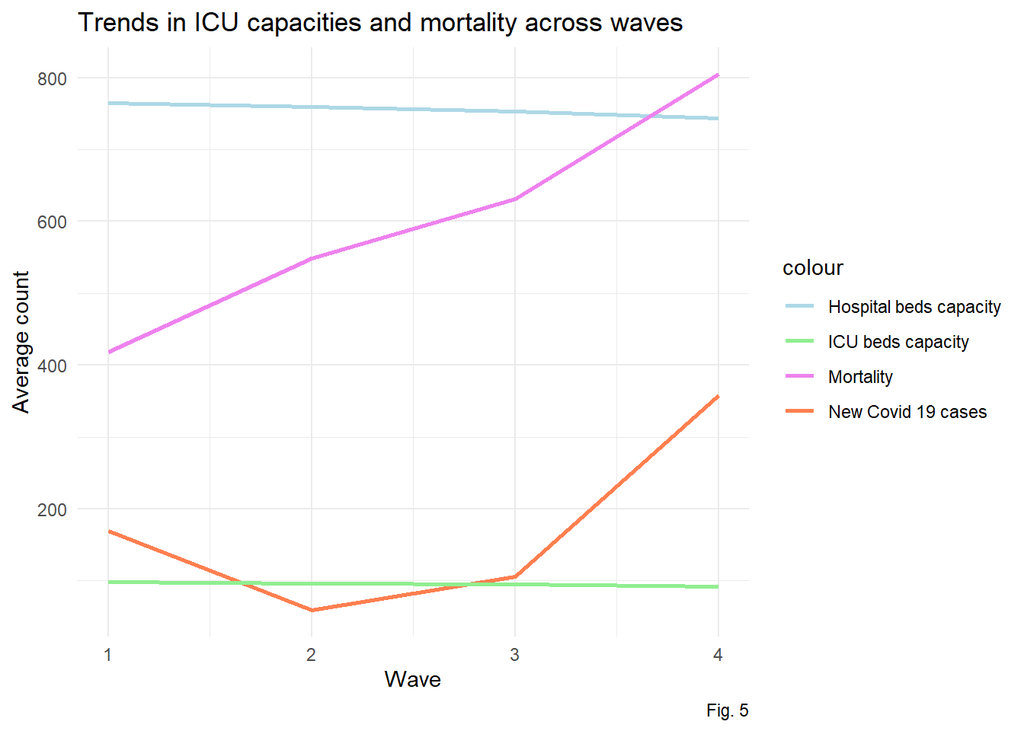

# Statistical tests for comparative analysis

# t-tests

```
##
##  Welch Two Sample t-test
##
## data:  subset_cbsas_data$actuals.icuBeds.capacity[subset_cbsas_data$wave == 1] and subset_cbsas_data$actuals.icuBeds.capacity[subset_cbsas_data$wave == 4]
## t = 0.9104, df = 7826.6, p-value = 0.3626
## alternative hypothesis: true difference in means is not equal to 0
## 95 percent confidence interval:
##  -7.326135 20.031874
## sample estimates:
## mean of x mean of y
##  98.37719  92.02432
```

# Multiple linear regression

fit a multiple linear regression model

```
##
## Call:
## lm(formula = actuals.deaths ~ factor(wave) + actuals.newCases +
##     actuals.icuBeds.capacity + actuals.hospitalBeds.capacity,
##     data = subset_cbsas_data)
##
## Residuals:
##      Min       1Q   Median       3Q      Max
## -14384.0    -20.8    107.8    209.8  19914.3
##
## Coefficients:
##                                  Estimate  Std. Error t value
## (Intercept)                   -355.183601   15.063967  -23.58
## factor(wave)2                  165.931894   18.153550    9.14
## factor(wave)3                  263.051496   17.969630   14.64
## factor(wave)4                  418.622987   19.040764   21.99
## actuals.newCases                 0.146046    0.004382   33.33
## actuals.icuBeds.capacity        -2.609662    0.149232  -17.49
## actuals.hospitalBeds.capacity    1.345506    0.018122   74.25
##                                          Pr(>|t|)
## (Intercept)                   <0.0000000000000002 ***
## factor(wave)2                 <0.0000000000000002 ***
## factor(wave)3                 <0.0000000000000002 ***
## factor(wave)4                 <0.0000000000000002 ***
## actuals.newCases              <0.0000000000000002 ***
## actuals.icuBeds.capacity      <0.0000000000000002 ***
## actuals.hospitalBeds.capacity <0.0000000000000002 ***
## ---
## Signif. codes:  0 '***' 0.001 '**' 0.01 '*' 0.05 '.' 0.1 ' ' 1
##
## Residual standard error: 925 on 26867 degrees of freedom
##   (341365 observations deleted due to missingness)
## Multiple R-squared:  0.9139, Adjusted R-squared:  0.9139
## F-statistic: 4.756e+04 on 6 and 26867 DF,  p-value: < 0.00000000000000022
```

# ANOVA

performing ANOVA to compare mortality to ICU bed capacity between waves

```
## Call:
##    aov(formula = lm_model)
##
## Terms:
##                 factor(wave) actuals.newCases actuals.icuBeds.capacity
## Sum of Squares     503223663      74407979305             164520537655
## Deg. of Freedom            3                1                        1
##                 actuals.hospitalBeds.capacity    Residuals
## Sum of Squares                     4716564782  22988121061
## Deg. of Freedom                             1        26867
##
## Residual standard error: 925.0009
## Estimated effects may be unbalanced
## 341365 observations deleted due to missingness
```

[output not shown]

# Intervention analysis: The impact of vaccinations and ICU beds capacity on new daily deaths

This section aims to explore the impact of two crucial factors, the ratios of the completed vaccinations and ICU bed capacities, on daily COVID-19-related deaths. Understanding the effectiveness of these interventions is vital for informed decision-making and future pandemic preparedness. The distribution of the number of new daily deaths as displayed by the boxplot in Fig. 9 shows that outliers were the order of the day across all waves. The largest number of deaths in any one particular day were recorded during the third wave.

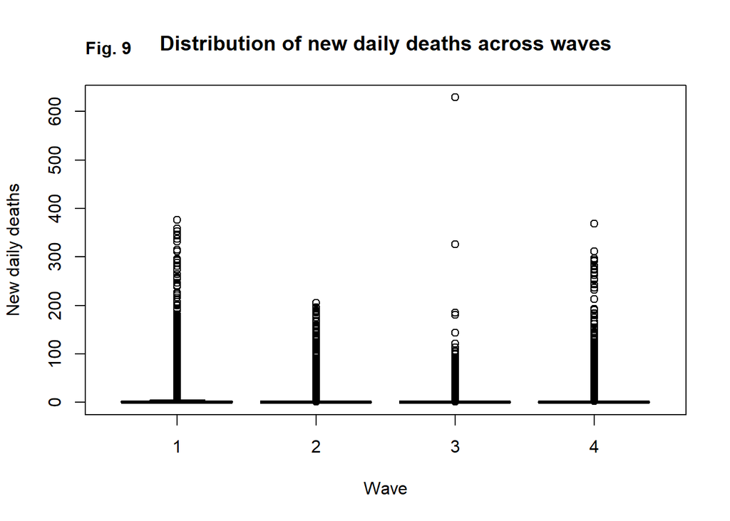

```
##                                    metrics.vaccinationsCompletedRatio
## metrics.vaccinationsCompletedRatio                         1.00000000
## metrics.icuCapacityRatio                                   0.14715473
## actuals.newDeaths                                         -0.05098375
##                                    metrics.icuCapacityRatio actuals.newDeaths
## metrics.vaccinationsCompletedRatio               0.14715473       -0.05098375
## metrics.icuCapacityRatio                         1.00000000        0.08868763
## actuals.newDeaths                                0.08868763        1.00000000
```

The correlation matrix reveals weak associations between the variables. Specifically, completed vaccinations and ICU bed capacity ratio show a negligible positive correlation (0.15), while the correlation between new daily deaths and both completed vaccinations (-0.05) and ICU bed capacity ratio (0.09) is very weak. These results suggest limited linear relationships, consequently implying that non-linear methods might be more suitable for modeling these variables, or there might be need to stratify the data into the various waves before computing the correlation.

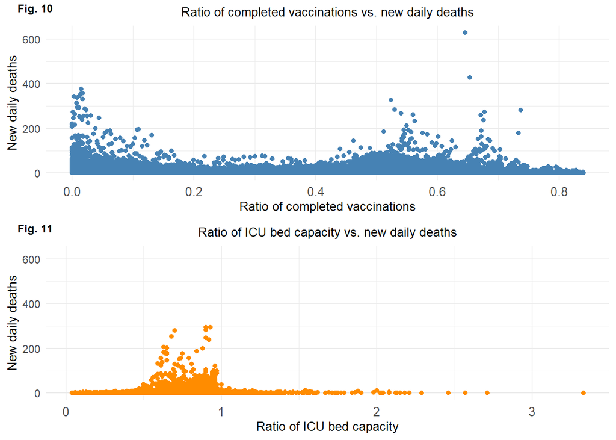

## Part 2

# Introduction

## Data Processing

#Data Sources and Integration

In this study, we integrated data from multiple sources to comprehensively analyze the impact of social determinants and vaccination rates on local hospital and ICU capacities during the COVID-19 pandemic. I obtained the data US_2022_ADI_Census_Block_Group_v4_0_1.csv data from (https://www.neighborhoodatlas.medicine.wisc.edu/).

The following steps outline the detailed data processing and integration procedures:

# Reading the Datasets:

Social Determinants Data: The social determinants data, which includes the Area Deprivation Index (ADI) and other socioeconomic factors, was obtained from the file US_2022_ADI_Census_Block_Group_v4_0_1.csv. This dataset provides valuable insights into the socioeconomic status of various regions, incorporating factors such as income, education, employment, and housing quality. The data was read using the fread function from the data.table package in R to ensure efficient handling of large datasets. CBSAs Timeseries Data: The timeseries data for Core-Based Statistical Areas (CBSAs), which includes detailed information on hospital and ICU bed usage, COVID-19 cases and deaths, and vaccination rates, was sourced from the file cbsas.timeseries.csv. This dataset tracks the temporal evolution of the pandemic and healthcare utilization across different metropolitan areas.

```
## [1] Inf
```

| GISJOIN | FIPS | ADI_NATRANK | ADI_STATERNK |
| --- | --- | --- | --- |
| G01000100201001 | 10010201001 | 76 | 5 |
| G01000100201002 | 10010201002 | 74 | 5 |
| G01000100202001 | 10010202001 | 82 | 6 |
| G01000100202002 | 10010202002 | 82 | 6 |
| G01000100203001 | 10010203001 | 71 | 4 |
| G01000100203002 | 10010203002 | 88 | 7 |

# Description of Data (US_2022_ADI_Census_Block_Group_v4_0_1.csv)

Social Determinants Data

Source: US_2022_ADI_Census_Block_Group_v4_0_1.csv link: https://www.neighborhoodatlas.medicine.wisc.edu/

# Description:

This dataset includes detailed information on various social determinants of health at the census block group level. The key variable of interest from this dataset is the Area Deprivation Index (ADI), which is a composite measure of socioeconomic disadvantage.

# Key Variables:

ADI_NATRANK: A numeric value representing the national rank of deprivation, with higher values indicating greater levels of socioeconomic disadvantage. Income, Education, Employment, Housing Quality: Various socioeconomic factors contributing to the overall ADI score.

#Summary of social determinants data

```
##    GISJOIN               FIPS              ADI_NATRANK
##  Length:242336      Min.   : 10010201001   Length:242336
##  Class :character   1st Qu.:130730303071   Class :character
##  Mode  :character   Median :280659501012   Mode  :character
##                     Mean   :284417739772
##                     3rd Qu.:420035030021
##                     Max.   :721537506022
##  ADI_STATERNK
##  Length:242336
##  Class :character
##  Mode  :character
##
##
##
```

# Basic Scatter plot of the first 20 data

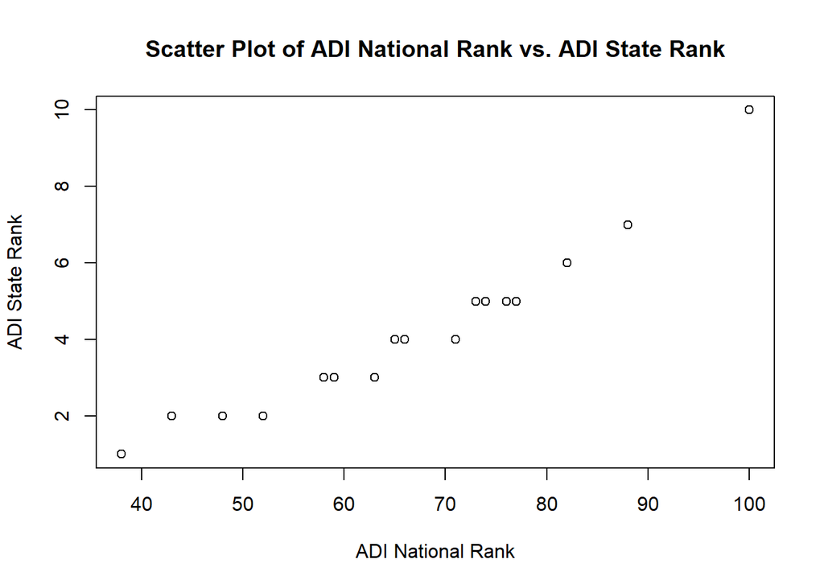

# Extracting County Codes:

| GISJOIN | FIPS | ADI_NATRANK | ADI_STATERNK | county_code |
| --- | --- | --- | --- | --- |
| G01000100201001 | 10010201001 | 76 | 5 | 010 |
| G01000100201002 | 10010201002 | 74 | 5 | 010 |
| G01000100202001 | 10010202001 | 82 | 6 | 010 |
| G01000100202002 | 10010202002 | 82 | 6 | 010 |
| G01000100203001 | 10010203001 | 71 | 4 | 010 |
| G01000100203002 | 10010203002 | 88 | 7 | 010 |

| date | country | state | county | fips | lat | long | locationId | actuals.cases | actuals.deaths | actuals.positiveTests | actuals.negativeTests | actuals.contactTracers | actuals.hospitalBeds.capacity | actuals.hospitalBeds.currentUsageTotal | actuals.hospitalBeds.currentUsageCovid | unused1 | actuals.icuBeds.capacity | actuals.icuBeds.currentUsageTotal | actuals.icuBeds.currentUsageCovid | unused2 | actuals.newCases | actuals.vaccinesDistributed | actuals.vaccinationsInitiated | actuals.vaccinationsCompleted | metrics.testPositivityRatio | metrics.testPositivityRatioDetails | metrics.caseDensity | metrics.contactTracerCapacityRatio | metrics.infectionRate | … |
| --- | --- | --- | --- | --- | --- | --- | --- | --- | --- | --- | --- | --- | --- | --- | --- | --- | --- | --- | --- | --- | --- | --- | --- | --- | --- | --- | --- | --- | --- | --- |
| 2020-05-08 | US | NA | NA | 10100 | NA | NA | iso1:us#cbsa:10100 | NA | NA | NA | NA | NA | NA | NA | NA | NA | NA | NA | NA | NA | NA | NA | NA | NA | 0.312 | NA | 0 | NA | NA | … |
| 2020-05-09 | US | NA | NA | 10100 | NA | NA | iso1:us#cbsa:10100 | NA | NA | NA | NA | NA | NA | NA | NA | NA | NA | NA | NA | NA | NA | NA | NA | NA | 0.230 | NA | 0 | NA | NA | … |
| 2020-05-10 | US | NA | NA | 10100 | NA | NA | iso1:us#cbsa:10100 | NA | NA | NA | NA | NA | NA | NA | NA | NA | NA | NA | NA | NA | NA | NA | NA | NA | 0.222 | NA | 0 | NA | NA | … |
| 2020-05-11 | US | NA | NA | 10100 | NA | NA | iso1:us#cbsa:10100 | NA | NA | NA | NA | NA | NA | NA | NA | NA | NA | NA | NA | NA | NA | NA | NA | NA | 0.210 | NA | 0 | NA | NA | … |
| 2020-05-12 | US | NA | NA | 10100 | NA | NA | iso1:us#cbsa:10100 | NA | NA | NA | NA | NA | NA | NA | NA | NA | NA | NA | NA | NA | NA | NA | NA | NA | 0.227 | NA | 0 | NA | NA | … |
| 2020-05-13 | US | NA | NA | 10100 | NA | NA | iso1:us#cbsa:10100 | NA | NA | NA | NA | NA | NA | NA | NA | NA | NA | NA | NA | NA | NA | NA | NA | NA | 0.222 | NA | 0 | NA | NA | … |

# Data Cleaning:

Before merging the datasets, it was essential to ensure that the relevant columns in the CBSAs timeseries data were in the appropriate numeric format. This conversion was crucial for accurate data analysis and integration. The columns converted included: actuals.hospitalBeds.currentUsageTotal: Total current usage of hospital beds. actuals.icuBeds.currentUsageTotal: Total current usage of ICU beds. actuals.vaccinationsCompleted: Total number of completed vaccinations.

| date | country | state | county | fips | lat | long | locationId | actuals.cases | actuals.deaths | actuals.positiveTests | actuals.negativeTests | actuals.contactTracers | actuals.hospitalBeds.capacity | actuals.hospitalBeds.currentUsageTotal | actuals.hospitalBeds.currentUsageCovid | unused1 | actuals.icuBeds.capacity | actuals.icuBeds.currentUsageTotal | actuals.icuBeds.currentUsageCovid | unused2 | actuals.newCases | actuals.vaccinesDistributed | actuals.vaccinationsInitiated | actuals.vaccinationsCompleted | metrics.testPositivityRatio | metrics.testPositivityRatioDetails | metrics.caseDensity | metrics.contactTracerCapacityRatio | metrics.infectionRate | … |
| --- | --- | --- | --- | --- | --- | --- | --- | --- | --- | --- | --- | --- | --- | --- | --- | --- | --- | --- | --- | --- | --- | --- | --- | --- | --- | --- | --- | --- | --- | --- |
| 2020-05-08 | US | NA | NA | 10100 | NA | NA | iso1:us#cbsa:10100 | NA | NA | NA | NA | NA | NA | NA | NA | NA | NA | NA | NA | NA | NA | NA | NA | NA | 0.312 | NA | 0 | NA | NA | … |
| 2020-05-09 | US | NA | NA | 10100 | NA | NA | iso1:us#cbsa:10100 | NA | NA | NA | NA | NA | NA | NA | NA | NA | NA | NA | NA | NA | NA | NA | NA | NA | 0.230 | NA | 0 | NA | NA | … |
| 2020-05-10 | US | NA | NA | 10100 | NA | NA | iso1:us#cbsa:10100 | NA | NA | NA | NA | NA | NA | NA | NA | NA | NA | NA | NA | NA | NA | NA | NA | NA | 0.222 | NA | 0 | NA | NA | … |
| 2020-05-11 | US | NA | NA | 10100 | NA | NA | iso1:us#cbsa:10100 | NA | NA | NA | NA | NA | NA | NA | NA | NA | NA | NA | NA | NA | NA | NA | NA | NA | 0.210 | NA | 0 | NA | NA | … |
| 2020-05-12 | US | NA | NA | 10100 | NA | NA | iso1:us#cbsa:10100 | NA | NA | NA | NA | NA | NA | NA | NA | NA | NA | NA | NA | NA | NA | NA | NA | NA | 0.227 | NA | 0 | NA | NA | … |
| 2020-05-13 | US | NA | NA | 10100 | NA | NA | iso1:us#cbsa:10100 | NA | NA | NA | NA | NA | NA | NA | NA | NA | NA | NA | NA | NA | NA | NA | NA | NA | 0.222 | NA | 0 | NA | NA | … |

# Filtering Data:

To maintain the integrity and accuracy of the analysis, rows with missing values (NA) in key columns were filtered out. Specifically, the analysis focused on complete cases for the following columns: actuals.hospitalBeds.currentUsageTotal actuals.icuBeds.currentUsageTotal actuals.vaccinationsCompleted

| date | country | state | county | fips | lat | long | locationId | actuals.cases | actuals.deaths | actuals.positiveTests | actuals.negativeTests | actuals.contactTracers | actuals.hospitalBeds.capacity | actuals.hospitalBeds.currentUsageTotal | actuals.hospitalBeds.currentUsageCovid | unused1 | actuals.icuBeds.capacity | actuals.icuBeds.currentUsageTotal | actuals.icuBeds.currentUsageCovid | unused2 | actuals.newCases | actuals.vaccinesDistributed | actuals.vaccinationsInitiated | actuals.vaccinationsCompleted | metrics.testPositivityRatio | metrics.testPositivityRatioDetails | metrics.caseDensity | metrics.contactTracerCapacityRatio | metrics.infectionRate | … |
| --- | --- | --- | --- | --- | --- | --- | --- | --- | --- | --- | --- | --- | --- | --- | --- | --- | --- | --- | --- | --- | --- | --- | --- | --- | --- | --- | --- | --- | --- | --- |
| 2021-01-14 | US | NA | NA | 10140 | NA | NA | iso1:us#cbsa:10140 | 2656 | 28 | NA | NA | NA | 54 | 45 | 4 | NA | 4 | 3 | 1 | NA | 26 | NA | 1220 | 86 | NA | NA | 36.4 | NA | 0.81 | … |
| 2021-01-21 | US | NA | NA | 10140 | NA | NA | iso1:us#cbsa:10140 | 2766 | 31 | NA | NA | NA | 56 | 47 | 4 | NA | 5 | 5 | 1 | NA | 13 | NA | 2351 | 207 | NA | NA | 20.9 | NA | 0.91 | … |
| 2021-01-28 | US | NA | NA | 10140 | NA | NA | iso1:us#cbsa:10140 | 2924 | 32 | NA | NA | NA | 52 | 39 | 3 | NA | 5 | 4 | 2 | NA | 50 | NA | 4495 | 568 | NA | NA | 30.1 | NA | 0.97 | … |
| 2021-02-04 | US | NA | NA | 10140 | NA | NA | iso1:us#cbsa:10140 | 3052 | 37 | NA | NA | NA | 53 | 36 | 1 | NA | 5 | 3 | 0 | NA | 13 | NA | 6463 | 937 | NA | NA | 24.6 | NA | 0.92 | … |
| 2021-02-11 | US | NA | NA | 10140 | NA | NA | iso1:us#cbsa:10140 | 3200 | 41 | NA | NA | NA | 55 | 45 | 2 | NA | 4 | 3 | NA | NA | 24 | NA | 8867 | 1645 | NA | NA | 35.1 | NA | 0.79 | … |
| 2021-02-18 | US | NA | NA | 10140 | NA | NA | iso1:us#cbsa:10140 | 3244 | 45 | NA | NA | NA | 57 | 48 | 1 | NA | 4 | 3 | NA | NA | 11 | NA | 9983 | 2674 | NA | NA | 8.4 | NA | 0.76 | … |

# Merging Datasets:

The key socioeconomic variable, ADI_NATRANK from the social determinants data, was converted to a numeric format to ensure compatibility with the CBSAs timeseries data. The filtered CBSAs timeseries data was then merged with the social determinants data using the cbind function in R, aligning the datasets by county codes. This step enabled the integration of socioeconomic information with healthcare utilization data, facilitating a comprehensive analysis of the impact of social determinants on hospital performance and pandemic outcomes.

| date | country | state | county | fips | lat | long | locationId | actuals.cases | actuals.deaths | actuals.positiveTests | actuals.negativeTests | actuals.contactTracers | actuals.hospitalBeds.capacity | actuals.hospitalBeds.currentUsageTotal | actuals.hospitalBeds.currentUsageCovid | unused1 | actuals.icuBeds.capacity | actuals.icuBeds.currentUsageTotal | actuals.icuBeds.currentUsageCovid | unused2 | actuals.newCases | actuals.vaccinesDistributed | actuals.vaccinationsInitiated | actuals.vaccinationsCompleted | metrics.testPositivityRatio | metrics.testPositivityRatioDetails | metrics.caseDensity | metrics.contactTracerCapacityRatio | metrics.infectionRate | … |
| --- | --- | --- | --- | --- | --- | --- | --- | --- | --- | --- | --- | --- | --- | --- | --- | --- | --- | --- | --- | --- | --- | --- | --- | --- | --- | --- | --- | --- | --- | --- |
| 2021-01-14 | US | NA | NA | 10140 | NA | NA | iso1:us#cbsa:10140 | 2656 | 28 | NA | NA | NA | 54 | 45 | 4 | NA | 4 | 3 | 1 | NA | 26 | NA | 1220 | 86 | NA | NA | 36.4 | NA | 0.81 | … |
| 2021-01-21 | US | NA | NA | 10140 | NA | NA | iso1:us#cbsa:10140 | 2766 | 31 | NA | NA | NA | 56 | 47 | 4 | NA | 5 | 5 | 1 | NA | 13 | NA | 2351 | 207 | NA | NA | 20.9 | NA | 0.91 | … |
| 2021-01-28 | US | NA | NA | 10140 | NA | NA | iso1:us#cbsa:10140 | 2924 | 32 | NA | NA | NA | 52 | 39 | 3 | NA | 5 | 4 | 2 | NA | 50 | NA | 4495 | 568 | NA | NA | 30.1 | NA | 0.97 | … |
| 2021-02-04 | US | NA | NA | 10140 | NA | NA | iso1:us#cbsa:10140 | 3052 | 37 | NA | NA | NA | 53 | 36 | 1 | NA | 5 | 3 | 0 | NA | 13 | NA | 6463 | 937 | NA | NA | 24.6 | NA | 0.92 | … |
| 2021-02-11 | US | NA | NA | 10140 | NA | NA | iso1:us#cbsa:10140 | 3200 | 41 | NA | NA | NA | 55 | 45 | 2 | NA | 4 | 3 | NA | NA | 24 | NA | 8867 | 1645 | NA | NA | 35.1 | NA | 0.79 | … |
| 2021-02-18 | US | NA | NA | 10140 | NA | NA | iso1:us#cbsa:10140 | 3244 | 45 | NA | NA | NA | 57 | 48 | 1 | NA | 4 | 3 | NA | NA | 11 | NA | 9983 | 2674 | NA | NA | 8.4 | NA | 0.76 | … |

# Plot For Relationship between ADI and Current Hostpital Beg Usage

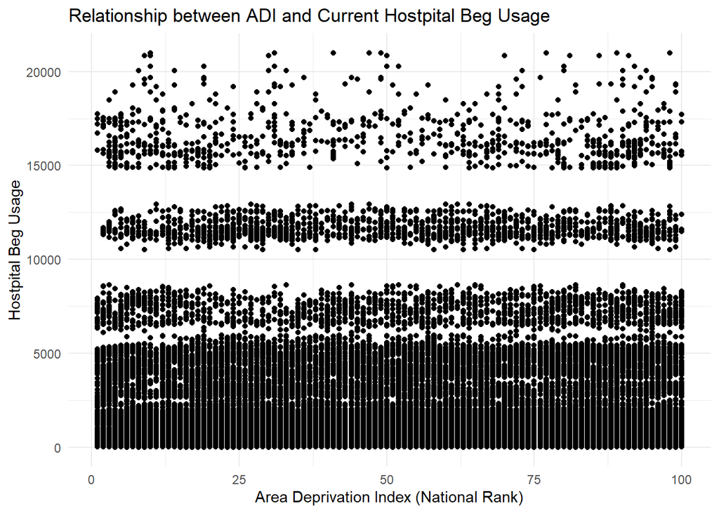

# Plot For Relationship between ADI and Vaccinations Completed

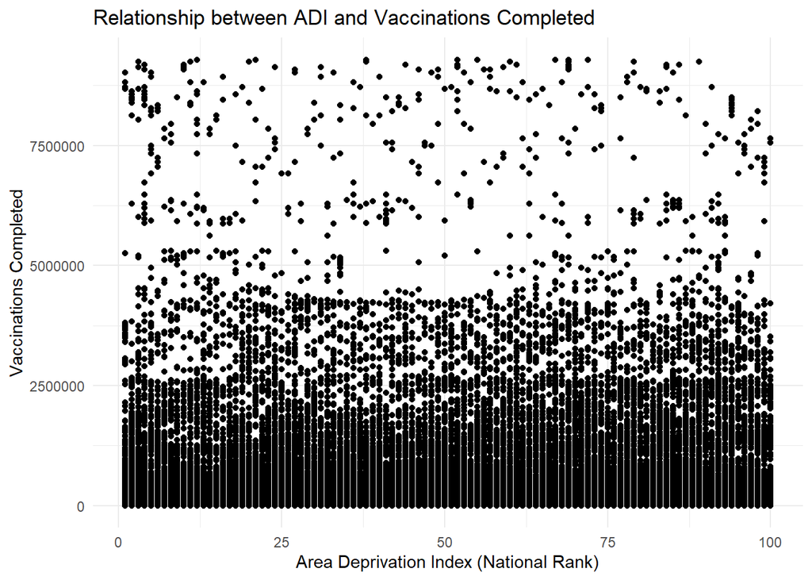

# Plot For Relationship between ADI and Icu Beds usage Total

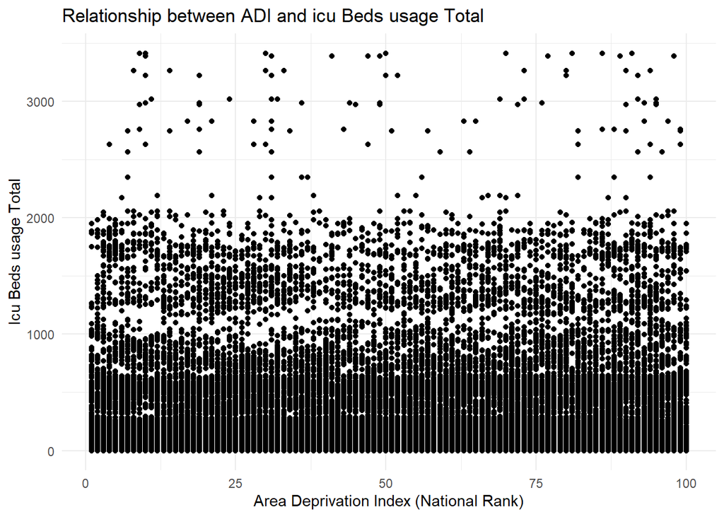

## Correlation Analysis

In this section, we investigate the relationships between hospital bed usage, ICU bed usage, completed vaccinations, and the Area Deprivation Index (ADI) at the county level. The correlation matrix provides insights into how these variables are interrelated, highlighting potential areas of influence and interaction.

```
##                                        actuals.hospitalBeds.currentUsageTotal
## actuals.hospitalBeds.currentUsageTotal                             1.00000000
## actuals.icuBeds.currentUsageTotal                                  0.98898623
## actuals.vaccinationsCompleted                                      0.84294276
## ADI_NATRANK                                                        0.00787942
##                                        actuals.icuBeds.currentUsageTotal
## actuals.hospitalBeds.currentUsageTotal                       0.988986230
## actuals.icuBeds.currentUsageTotal                            1.000000000
## actuals.vaccinationsCompleted                                0.798650347
## ADI_NATRANK                                                  0.007763773
##                                        actuals.vaccinationsCompleted
## actuals.hospitalBeds.currentUsageTotal                    0.84294276
## actuals.icuBeds.currentUsageTotal                         0.79865035
## actuals.vaccinationsCompleted                             1.00000000
## ADI_NATRANK                                               0.01040918
##                                        ADI_NATRANK
## actuals.hospitalBeds.currentUsageTotal 0.007879420
## actuals.icuBeds.currentUsageTotal      0.007763773
## actuals.vaccinationsCompleted          0.010409183
## ADI_NATRANK                            1.000000000
```

The correlation analysis reveals strong positive relationships between general hospital bed usage, ICU bed usage, and completed vaccinations, indicating that these variables are closely interrelated. However, the Area Deprivation Index (ADI) shows negligible correlation with bed usage and vaccination rates, suggesting that socioeconomic factors captured by the ADI do not have a straightforward impact on these healthcare metrics. This underscores the need for more complex, potentially non-linear models to fully understand the influence of social determinants on healthcare capacity and outcomes.

## Data Visualization and Analysis Report

To investigate the relationships between hospital/ICU bed usage, vaccination rates, and social determinants, several scatter plots were created. These visualizations help to identify trends and potential correlations within the dataset. Below are the detailed descriptions and interpretations of these plots.

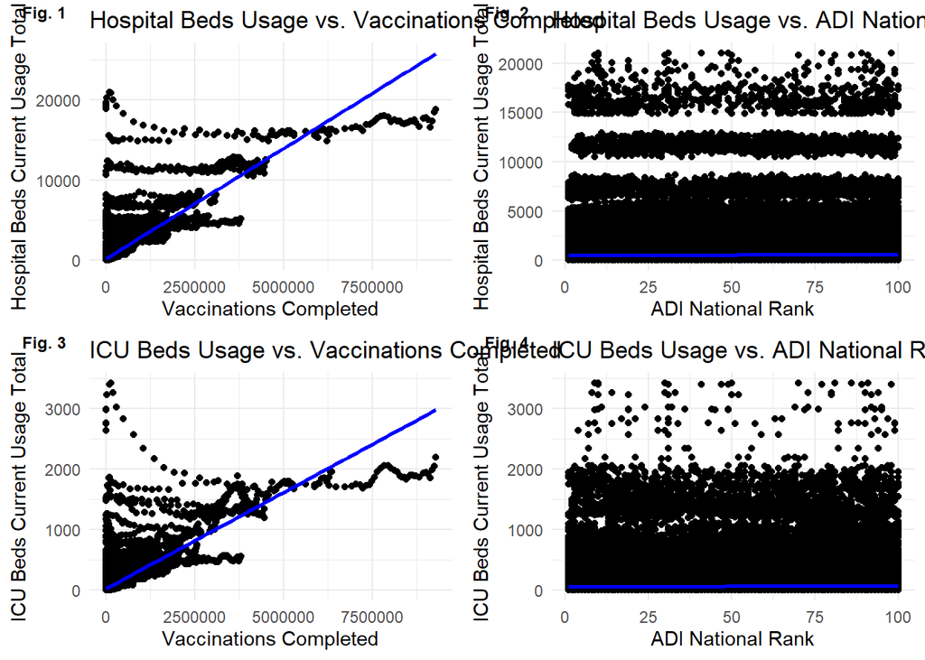

## Multiple linear regression

fit a multiple linear regression model

```
##
## Call:
## lm(formula = actuals.hospitalBeds.currentUsageTotal ~ actuals.vaccinationsCompleted +
##     ADI_NATRANK, data = merged_data)
##
## Residuals:
##     Min      1Q  Median      3Q     Max
## -8734.1  -183.9  -154.2   -69.9 20542.0
##
## Coefficients:
##                                    Estimate    Std. Error t value
## (Intercept)                   169.682246691   3.744567281  45.314
## actuals.vaccinationsCompleted   0.002751326   0.000003615 761.034
## ADI_NATRANK                    -0.051607995   0.063867766  -0.808
##                                          Pr(>|t|)
## (Intercept)                   <0.0000000000000002 ***
## actuals.vaccinationsCompleted <0.0000000000000002 ***
## ADI_NATRANK                                 0.419
## ---
## Signif. codes:  0 '***' 0.001 '**' 0.01 '*' 0.05 '.' 0.1 ' ' 1
##
## Residual standard error: 895.5 on 235949 degrees of freedom
##   (6384 observations deleted due to missingness)
## Multiple R-squared:  0.7106, Adjusted R-squared:  0.7106
## F-statistic: 2.896e+05 on 2 and 235949 DF,  p-value: < 0.00000000000000022
```

```
##
## Call:
## lm(formula = actuals.icuBeds.currentUsageTotal ~ actuals.vaccinationsCompleted +
##     ADI_NATRANK, data = merged_data)
##
## Residuals:
##     Min      1Q  Median      3Q     Max
## -1068.5   -24.7   -20.7   -10.1  3343.0
##
## Coefficients:
##                                    Estimate    Std. Error t value
## (Intercept)                   22.8787580354  0.5102172777  44.841
## actuals.vaccinationsCompleted  0.0003175325  0.0000004926 644.609
## ADI_NATRANK                   -0.0038601696  0.0087023240  -0.444
##                                          Pr(>|t|)
## (Intercept)                   <0.0000000000000002 ***
## actuals.vaccinationsCompleted <0.0000000000000002 ***
## ADI_NATRANK                                 0.657
## ---
## Signif. codes:  0 '***' 0.001 '**' 0.01 '*' 0.05 '.' 0.1 ' ' 1
##
## Residual standard error: 122 on 235949 degrees of freedom
##   (6384 observations deleted due to missingness)
## Multiple R-squared:  0.6378, Adjusted R-squared:  0.6378
## F-statistic: 2.078e+05 on 2 and 235949 DF,  p-value: < 0.00000000000000022
```

The regression models aim to predict hospital bed usage and ICU bed usage based on two predictor variables: vaccinations completed (actuals.vaccinationsCompleted) and the Area Deprivation Index (ADI_NATRANK). In both models, the intercept represents the expected value of the outcome variable when all predictor variables are zero. The coefficients indicate the estimated change in the outcome variable for a one-unit increase in the corresponding predictor, holding other predictors constant. For hospital bed usage, each additional completed vaccination is associated with an estimated increase of 0.00275 in hospital bed usage, while each unit increase in the Area Deprivation Index is associated with a decrease of 0.0516 in hospital bed usage, although the latter is not statistically significant (p = 0.419).

Similarly, for ICU bed usage, each additional completed vaccination is associated with an estimated increase of 0.0003175 in ICU bed usage, while the effect of the Area Deprivation Index is not statistically significant (p = 0.657). The models have high multiple R-squared values (0.7106 for hospital bed usage and 0.6378 for ICU bed usage), indicating that a substantial proportion of the variability in bed usage is explained by the predictor variables. Additionally, the extremely low p-values for the F-statistics (< 0.0001) indicate that both models are statistically significant, suggesting that the predictors jointly have a significant effect on bed usage.

## Anova analysis

```
## Call:
##    aov(formula = hospital_model)
##
## Terms:
##                 actuals.vaccinationsCompleted  ADI_NATRANK    Residuals
## Sum of Squares                   464469701474       523579 189203789934
## Deg. of Freedom                             1            1       235949
##
## Residual standard error: 895.4799
## Estimated effects may be unbalanced
## 6384 observations deleted due to missingness
```

```
## Call:
##    aov(formula = icu_model)
##
## Terms:
##                 actuals.vaccinationsCompleted ADI_NATRANK  Residuals
## Sum of Squares                     6186613386        2929 3512666166
## Deg. of Freedom                             1           1     235949
##
## Residual standard error: 122.0139
## Estimated effects may be unbalanced
## 6384 observations deleted due to missingness
```

The provided ANOVA output assesses the significance of the predictor variables, actuals.vaccinationsCompleted and ADI_NATRANK, in explaining the variability in hospital bed usage (first output) and ICU bed usage (second output), respectively.

# For the hospital model:

The sum of squares represents the variation attributed to each predictor variable and the residual variation (unexplained by the predictors). The degrees of freedom indicate the number of independent pieces of information used to estimate the variation for each predictor and the residuals. The residual standard error represents the average amount that the observed hospital bed usage deviates from the predicted values. The estimated effects may be unbalanced, suggesting potential variability or non-normality in the data. 6384 observations were deleted due to missingness.

# For the ICU model:

Similarly, the sum of squares, degrees of freedom, and residual standard error are provided for the predictor variables and residuals. The estimated effects may also be unbalanced. 6384 observations were deleted due to missingness. Overall, these ANOVA outputs help assess the significance of the predictor variables in explaining the variability in hospital and ICU bed usage, providing insights into their contributions to the models.

## Conclusion

This study provides a comprehensive analysis of hospitals’ bed capacity performance during different phases of the Covid-19 pandemic, incorporating insights from both Part 1 and Part 2 analyses. The results revealed a concerning trend of declining ICU bed capacity, contrary to the anticipated increase needed to accommodate the rising number of patients amidst the surge in new daily cases. This discrepancy underscores the critical importance of maintaining and possibly enhancing ICU capacities over time, particularly during successive waves of pandemics. By addressing this disparity, healthcare systems can better adapt and respond to the evolving challenges posed by such crises. Moreover, the insights drawn from both parts of the study can significantly inform future healthcare strategies, emphasizing the necessity for sustained preparedness and effective resource allocation in anticipation of and response to pandemics. By incorporating these findings into policy making and planning efforts, healthcare systems can enhance their resilience and capacity to mitigate the impact of future public health emergencies.